# Introduction to R programming for statistical inference in biology

Alfonso Rojas Mora, Laboratory of Ecology and Epidemiology of Parasites, University of Neuchatel

# Using R for the first time

R is an open source software based on the language of S-plus, its paid equivalent. Nowadays R is one of the main statistical softwares used across all disciplines. Like any software, it has it own advantages and disadvantages.

Adavantages:

- Freeware.
- Most new statistical methods are first implemented in R.
- Open source.
- Documentation is available in the internet.
- Plenty of forums with people willing to provide help.

Disadvantages:

- Command line (is this really a disadvantage?).
- It does not have a GUI (but R studio solved this).
- Learning curve can be slow.
- Is there any real disadvantage?

## Getting started

First of all, you need to download and install R and R studio in your computer. Both softwares are available for Windows, iOS, and Linux. They can be found at:

- R: https://cran.r-project.org/
- r Studio: https://www.rstudio.com/

**Note:** It is important to keep in mind that R has to be installed before installing r Studio.

## How should my rStudio GUI should look like?

No matter what computer and OS you are using, your rStudio device should always contain four windows in it: Script, Console, Environment, and viewer (for plots, help, packages).

[figure not shown]

## Scripts are the best way to organize your workflow

Always work on a script. It does not only looks more organized but:

- You can always go back to old analyses, and run them without having to re-write the whole code.
- Easy to review, and thus prevent any mistakes in your analysis.
- Easy to share, which is a key point of open science.
- You can reuse them for other projects.

A clean script always contains:

- A header containing the title of the project, author(s), and date

  ```r
  ###### Data Analysis
  ###### A coccidian infection affects migratory restlessness of a passerine bird during stopover
  ###### D. Hebinger, Y. Vortman, J.L. Perret, J.C. Koella, and A. Rojas Mora
  ###### Oikos 2021
  ```

- A command to clean your environment.

  ```r
  rm(list = ls())
  ```

- A section to load the libraries that you will use in your analyses.

  ```r
  libraries_for_analysis <- c("library1", "library2","etc")
  sapply(libraries_for_analysis, library, character.only = TRUE)
  ```

- A section to load and clean data.

  ```r
  setwd("./my_working_directory")
  data_table <- read.table(file = "my_table.txt")
  clean data <- data_table %>% # this is a pipeline
                  commands_to_clean_data(parameters)
  ```

- Finally, your analyses.

**NOTE:** Always remember to put a lot of comments on your script, as it is the most efficient way to keep track of what you did. Comments also will help other peers to understand your script. Comments are not executed by R, so feel free to use them.

```r
# Every comment in R starts with the symbol '#' and all the text following it will not be executed by R for that line of code.
# This is a comment. To make our life easier and our work more professional, r Studio has a really nice feature where any text between 5 consequtive hashtags will create a section for your script.
##### This is my new section #####
```

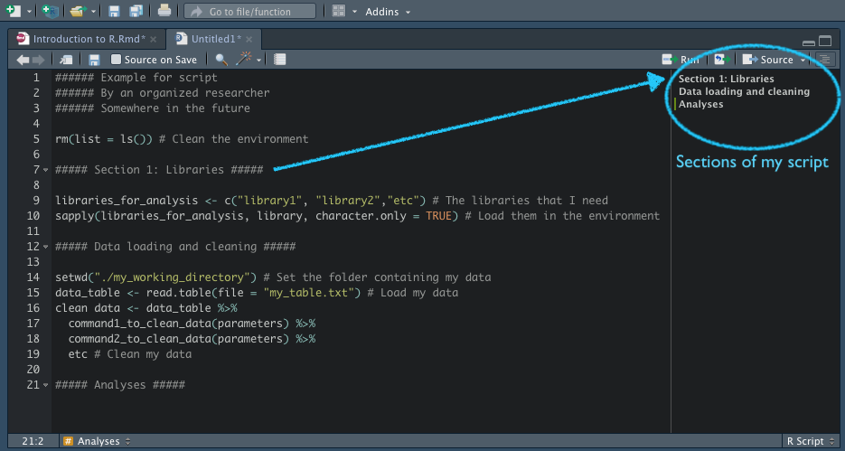

## Libraries

The environment in R does not have all the tools that you might need loaded, however there are various base packages that are loaded every time you start a new session. Libraries contain commands that are specific to certain functionalities (e.g. data management, statistical analysis, visualization tools, etc.), and they can be easily downloaded and install from repositories (e.g. CRAN). Fortunately, this is automatically done by R if you have an internet connection.

### Installing libraries

You can type and execute the following command:

```r
install.packages('library_name')
```

Alternatively, you can go to Tools -> Install packages, and there you can look for the library that you would like to install.

**NOTE: It is recommended to install the dependencies of the library that you are willing to install.**

### Loading libraries

You can load your libraries in the environment using the following command:

```r
library(library_name)
```

ALternatively, you can go to the “Packages” tab on the visual panel of r Studio and click on the libraries that you would like to load. However, I strongly recommend to type the command above and keep it on your script, like that your script will always load the necesary libraries for your task.

#### Exercise

Try to install the following libraries:

- tidyr
- dplyr
- broom
- ggplot2
- gridExtra
- ggfortify
- car

## Getting started with command line

Let us get started by using R as a calculator.

```r
# You can do simple operations exactly as done in a calculator:
1 + 1
```

```
## [1] 2
```

```r
# And you can do it line by line or having several in a line separated by a semicolon
2 * 3 ; 2^3 ; 10 / 4
```

```
## [1] 6
```

```
## [1] 8
```

```
## [1] 2.5
```

```r
# R uses standard precedence rules
(10 + 2*8) / 10
```

```
## [1] 2.6
```

```r
# R also contains common mathematical expresions such as:
log(1) ; sin(pi)
```

```
## [1] 0
```

```
## [1] 1.224647e-16
```

## Getting help in R

Each command has a help page with examples, and this is the main tool used to learn R. Within R, you can use commands to get help such as:

```r
# Alternative 1
?log
# Alternative 2
help(log)
```

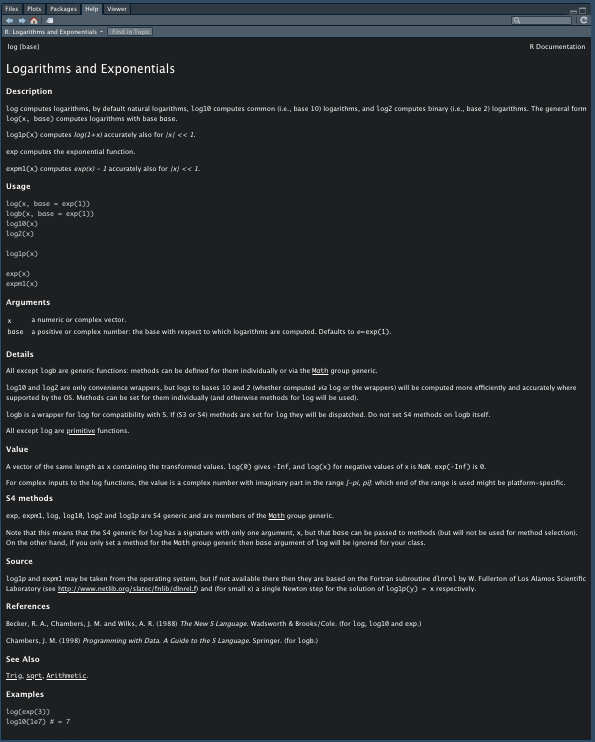

Additionally, you can use queries that are less specific or just load the whole help page.

```r
# Start the documentation of R
help.start()
# Display commands related to a general query
help.search('my_query_word')
```

Finally, **the most important tool to obtain help in R is Google**. There you will easily find the documentation for R and various libraries. Also, there are various forums where people asks and solve questions about R, so do not hesistate to check those.

## Adding objects to the environment

To this point, you should be able to do simple operations with R and execute simple commands, however we did not store any of the results yet. In R, everything is stored in objects, and the notation is quite simple:

```r
# Create your object to store your result
result <- 1 + 1
# Call your result
result
```

```
## [1] 2
```

R is very flexible on what can be stored in an object, and objects can thus contain data tables, figures, statistical tests, or even all of that (this is a type of object called list).

Within this frame, the most powerful feature of R is vectorial operations. An object containing a set of numbers can be refer as a vector, however this operations work in a simpler way than linear algebra. Instead, operations between vectors are executed by matching the index of each element within the vector. This means that the first element of vector 1 will be matched with the first element of vector 2, and so on. For example, the sum of two vectors in R would work as:

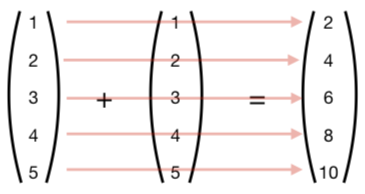

We can confirm the above in R by creating two vectors from 1 to 5 and doing the sum of them:

```r
vector_1 <- c(1:5) # concatenate 1 to 5, try typing ?c
vector_2 <- seq(from = 1, to = 5, by = 1) # make the sequence from 1 to 5 with steps of 1
vector_1 + vector_2
```

```
## [1]  2  4  6  8 10
```

## Indexing an object

As mentioned above, objects can contain 1 or various elements within them. Thus, at times you might just be interested in one single element of an object, and to extract it we would use indexing. Lets say you are interested in the third object of the sum between vector 1 and vector 2.

```r
vector_1 <- c(1:5) # concatenate 1 to 5, try typing ?c
vector_2 <- seq(from = 1, to = 5, by = 1) # make the sequence from 1 to 5 with steps of 1
result <- vector_1 + vector_2 # now we store our result in an object
result[3] # we use the square brackets to index our object
```

```
## [1] 6
```

Above we managed to obtain the third element of our object, which is 6. One important feature of indexing, is that we can use conditional statements to index objects. For example, imagine you are only interested in values that are larger than 5.

```r
vector_1 <- c(1:5) # concatenate 1 to 5, try typing ?c
vector_2 <- seq(from = 1, to = 5, by = 1) # make the sequence from 1 to 5 with steps of 1
result <- vector_1 + vector_2 # now we store our result in an object
result[result > 5] # now we use a conditional statement to index the object
```

```
## [1]  6  8 10
```

It is important to keep in mind that only elements where our condition is true will be kept during the indexing. This is a very important tool to tidy data, as your objects will rarely be ordered as the current example. So lets take a look at what the conditional statement returns:

```r
result > 5
```

```
## [1] FALSE FALSE  TRUE  TRUE  TRUE
```

Does this correspond to what we indexed above?

## Conditional statements

Above we used a conditional statement, which is characterized by having either TRUE or FALSE as elements. In R they are also called logical expressions, as we will later see in the classes of objects that are stored in the R environment. An useful feature of logical objects, is that TRUE is coded as 1 while FALSE is coded as 0. Bellow you can find some of the most common logical operators in R:

| In R | For us | Example |
| --- | --- | --- |
| == | Equal to | result == 4 |
| != | Does not equal to | result != 4 |
| <, >, <=, >= | Less than, greater than, less or equal, greater or equal | result <= 4 |
| & | And | result > 2 & result < 6 |
| \| | Or | result > 2 \| result < 6 |

### Exercise

Try to put in console the examples on the table above. What are your results?

## Matrices

Let us now extend our objects to two dimensions: rows and columns. While it might seem more complicated at first, all the above concepts will work for matrices - and later on tables, which are known as data.frames in R-.

```r
my_matrix <- matrix(data = 1:12, # sequence of numbers from 1 to 12
                    nrow = 4, # 4 rows
                    ncol = 3, # 3 columns
                    byrow = FALSE) # Fill the matrix by columns
my_matrix
```

```
##      [,1] [,2] [,3]
## [1,]    1    5    9
## [2,]    2    6   10
## [3,]    3    7   11
## [4,]    4    8   12
```

We can similarly index matrices and data frames using square brackets, but we will now need two dimensions within them.

```r
# Slice the second column of my_matrix
my_matrix[,2]
```

```
## [1] 5 6 7 8
```

```r
# Slice the first row of my_matrix
my_matrix[1,]
```

```
## [1] 1 5 9
```

```r
# Take the element in the third row and the first column
my_matrix[3,1]
```

```
## [1] 3
```

**WARNING** When you would like to work on your data table (or data frame, using the correct jaRgon), you can and will use the same sintax. If you have any doubts, please do not hesitate to ask any question.

## Data types in R

There are various data types in R, but we will mainly focus on the following:

| Data Type | Description | Example |
| --- | --- | --- |
| *logical* | TRUE and FALSE | TRUE |
| *character* | Character string | "This is a character string |
| *numeric* | Integers and real numbers | 1, 5.1 |
| *factor* | A special case of character, where one has levels | treatment1, treatment2 |

## Exercise sheet 1

Please open the exercise sheet 1 and try to solve the exercises. Remember that this will not be graded, though I highly recommend that you invest time in it, as this is the only way that you will really learn during this course. And remember, you will need a lot of error to learn:

[figure not shown]